# A Foray into Text Mining

Gamal Gabr

09 March, 2022

```r
#suppress warnings globally
options(warn=-1)
```

```r
options(scipen = 999)              #suppress the appearance of scientific notation throughout the analysis
```

```r
# load necessary libraries
library(tidytext)
library(tidyverse)
library(rvest)
library(ggplot2)
library(sentimentr)
library(gridExtra)
library(kableExtra)
library(lubridate)
```

### PROJECT MISSION AND RESEARCH FINDINGS

I encountered an interesting online agency known as Breakroom, who self-describe as ‘the people-powered job comparison site for hourly work’. They conduct research examining employee satification in the workplace. In 2020, their research suggested that Aldi employees were the happiest of supermarket employees with Morrisons staff being the least satisfied of supermarket employees.

I was curious to see whether a little webscraping coupled with subsequent textual/sentiment analysis could corroborate this. I set out on an interesting adventure : I was on a expedition into the fascinating world of sentiment analysis! Sentiment analysis is a form of text analytics that generally entails analysing textual output, whether it be a review or a book, and producing an overall score that reflects the corresponding level of positivity contained within the respective material.

My first mission was to obtain some data to analyse. Employing the specialised *SelectorGadget* Google Chrome Extension tool and the superb *Rvest* package for R, I was able to extract the CSS Selector nodes encoding reviews for Aldi and Morrisons employees from the *Indeed* website. I obtained four types of information from the `Indeed` website: the main review nodes provided by employees, in addition to nodes pertaining to the cons, pros and dates of the reviews.

In no way do I claim that the findings in this mini-project are suitable for making definitive statements. This project was largely an exercise in curiousity and is primarily intended to showcase the ease with which sentiment analysis can be conducted in the programming language of R. There are clear methodological shortcomings in this research, however I shall spare you the pain of enumerating them!

### KEY FINDINGS

I obtained the raw data using the following code stream:

```r
#establish empty dataset
ALDI.df <- data.frame(DATE=character(),
                       DATE=character(),
                       OPINION=character(),
                       PROS=character(),
                       CONS=character(),


                stringsAsFactors=FALSE)

#command rvest to cycle through specified pages

for (i in seq(0, 2000, 20)){
             url_ds <- paste0('https://uk.indeed.com/cmp/Aldi/reviews?start=',i)
 var <- read_html(url_ds)

  #instuct rvest to read HTML
   DATE <-  var %>%
html_nodes('.cmp-ReviewAuthor') %>%
     html_text() %>%
    str_extract("(\\w+.+)+")

  #instuct rvest to read Review HTML
  OPINION <- var %>%
    html_nodes('.cmp-NewLineToBr-text') %>%
    html_text() %>%
    str_extract("(\\w+).+")

     #extract pros
  PROS <-var %>%
       html_nodes('.cmp-ReviewProsCons-prosText') %>% html_text() %>%
         str_extract("(\\w+).+")

   #instuct rvest to read CONS HTML
  CONS <-var %>%
       html_nodes(' .cmp-ReviewProsCons-consText ') %>% html_text() %>%
         str_extract("(\\w+).+")

   #bind collected data together
ALDI.df <- rbind(ALDI.df, as.data.frame(cbind(DATE,
                                                    OPINION, PROS,CONS)))}


#now create a separate data frame for Morrisons

MORRISONS.df <- data.frame(DATE=character(),
                       DATE=character(),
                       OPINION=character(),
                       PROS=character(),
                       CONS=character(),


                       stringsAsFactors=FALSE)
for (i in seq(0, 2000, 20)){
             url_ds <- paste0('https://uk.indeed.com/cmp/Wm-Morrisons-Supermarkets/reviews?start=',i)
  var <- read_html(url_ds)

  # Date
   DATE <-  var %>%
html_nodes('.cmp-ReviewAuthor') %>%
     html_text() %>%
    str_extract("(\\w+.+)+")

  # Actual Review
  OPINION <- var %>%
    html_nodes('.cmp-NewLineToBr-text') %>%
    html_text() %>%
    str_extract("(\\w+).+")

     #extract pros
  PROS <-var %>%
       html_nodes('.cmp-ReviewProsCons-prosText') %>% html_text() %>%
         str_extract("(\\w+).+")

    #instuct rvest to read CONS HTML
  CONS <-var %>%
       html_nodes(' .cmp-ReviewProsCons-consText ') %>% html_text() %>%
         str_extract("(\\w+).+")

    #bind collected data together
MORRISONS.df <- rbind(MORRISONS.df, as.data.frame(cbind(DATE,
                                                    OPINION, PROS,CONS)))}

I decided to provide this dataframe with a group identifier - Morrisons employees.


ALDI.df$company<-rep("ALDI", times = 1270)
MORRISONS.df$company<-rep("MORRISONS", times = 1855)


#Combine dataframes
COMBINATION.df<-bind_rows(ALDI.df, MORRISONS.df)

write.csv(COMBINATION.df, file = "COMBINEDREVIEWS.csv")
```

I have opted to withhold displaying the collected dataframe in its raw form. Whilst the data used in this analysis is publicly available on the `Indeed` website and does not include names; I have still decided to entirely avoid entering the quagmire of ethical greyness associated with the usage of information in which questions relating to annoymity may arise.

### CLEANING THE DATA

```r
#load the formerly saved dataframe
#COMBINED.df <- read.csv('COMBINEDREVIEWS.csv')
#COMINDED.df<-read.csv("C:/Users/gamal/Desktop/SentimentAnalysisMA/Combinedreviews.csv")
COMBINED.df <- read.csv('Combinedreviews.csv')
```

```r
# convert variables from list to character
COMBINED.df$DATE<-as.character(COMBINED.df$DATE)

COMBINED.df$OPINION<-as.character(COMBINED.df$OPINION)

COMBINED.df$PROS<-as.character(COMBINED.df$PROS)

COMBINED.df$CONS<-as.character(COMBINED.df$CONS)
```

The original data contained in the `date` section was accompanied by a host of irrelevant information;I wanted to extract the date alone. Here is the code I used:

```r
#extract date from surrounding text
library(stringr)
COMBINED.df$DATE<-str_extract(COMBINED.df$DATE,"([0-9]{1,2})[- .]([a-zA-Z]+)[- .]([0-9]{4})" )
```

```r
#correct date format
COMBINED.df$DATE<-dmy(COMBINED.df$DATE)
```

```r
#group by month/year
COMBINED.df$Month_Yr <- format(as.Date(COMBINED.df$DATE), "%Y-%m")
```

```r
#extract Year as separate column
COMBINED.df$Year<-as.numeric(format(COMBINED.df$DATE, "%Y"))
```

```r
#extract month as separate variable
COMBINED.df$month<-as.numeric(format(COMBINED.df$DATE, "%m"))
```

```r
#recruit lubridate to extract month
COMBINED.df = COMBINED.df %>%
mutate(Month=floor_date(DATE, "month"))
```

```r
#remove NA entries
COMBINED.df<-COMBINED.df%>%drop_na()
```

```r
#eliminate duplicates based on opinions
COMBINED.df<-COMBINED.df[!duplicated(COMBINED.df$OPINION), ]
```

During my initial attempts to analyse the sentiment contained within text, I found that some of the packages currently used for sentiment analysis purposes were beset with unacceptable limitations. Of particular concern, a number of the packages that I encountered did not adequately address negations. For instance, such packages typically failed to clearly distinguish between phrases such as it was good and it was not good. Thankfully, I eventually discovered the par excellence sentimentr package which takes into account the impact of various valence shifters (i.e. amplifiers, downtoners and negators) when calculating sentiment. If you are interested in obtaining a more in-depth analysis of how the *sentimentr* package calculates sentiment, I would recommend following this [link](https://www.semion.io/doc/a-review-of-sentiment-computation-methods-with-r-packages)

### DEMONSTRATION OF SENTIMENTR ANALYSIS AT WORK:

The *sentiment_by* function of the `sentimentr` packages aggregates/averages scores for selected sections of text. Below, is a demonstration of sentimentr at work!

```r
sentiment_by('I do not like jaffa cakes. I hate being chased by giant squirrels', by=NULL)
```

|  | element_id | word_count | sd | ave_sentiment |
| --- | --- | --- | --- | --- |
| 1 | 1 | 13 | 0.05610836 | -0.2437987 |

```r
sentiment_by('I like jaffa cakes. I love being chased by giant squirrels', by=NULL)
```

|  | element_id | word_count | sd | ave_sentiment |
| --- | --- | --- | --- | --- |
| 1 | 1 | 11 | 0.02366924 | 0.2667367 |

In accordance with expectation, `sentimentr` scores the first and second block of sentences negatively and positively respectively.

For a little more nuance, the *sentiment* function can be used for the breakdown of sentiment in relation to individual sentences

```r
sentiment('I do not like jaffa cakes. I hate being chased by giant squirrels', by=NULL)
```

|  | element_id | sentence_id | word_count | sentiment |
| --- | --- | --- | --- | --- |
| 1 | 1 | 1 | 6 | -0.2041241 |
| 2 | 1 | 2 | 7 | -0.2834734 |

### CLEAN TEXT USING GENERIC CLEANER

For usage in previous text mining projects, I constructed a simple function that cleans text. Here, I summoned its aid:

```r
#construct text cleaner
Text.cleaner = function(x)

{x = gsub("&amp","", x)

x = gsub("(RT)((?:\\b\\w*@\\w+)+)","", x)

x= gsub("^RT","", x)

#remove @ individuals

x= gsub("@\\w+","", x)

# remove punctuation

x= gsub("[[:punct:]]","", x)

# eliminate digits

x= gsub("[[:digit:]]+\\s","", x)

# eliminate html links

x= gsub("http\\w+","", x)

#eliminate unnecessary spaces

x= gsub("[ \t]{2,}"," ", x)

x= gsub("^\\s+|\\s+$", "", x)

# remove emojis

x= iconv(x, "latin1", "ASCII", sub="")

#correct possesives

x= gsub("'s","", x)



try.error = function(z) #convert text to lowercase
{
y = NA
try_error = tryCatch(tolower(z), error=function(e) e)
if (!inherits(try_error, "error"))
y = tolower(z)
return(y)
}
x = sapply(x, try.error)
return(x)}
```

```r
# apply text cleaning function defined above to all relevant text

COMBINED.df$OPINION<-Text.cleaner(COMBINED.df$OPINION)


COMBINED.df$PROS<-Text.cleaner(COMBINED.df$PROS)


COMBINED.df$CONS<-Text.cleaner(COMBINED.df$CONS)
```

After purging the text of irregularities, I employed the *sentiment_by* function to obtain the average sentiment score per review. This function attempts to quantify the valence and polarity of particular chunks of text. Higher scores are associated with higher levels of positive sentiment.

```r
#obtain average sentiment per review
sentiment.df<-sentiment_by(get_sentences(COMBINED.df$OPINION))
```

```r
#combine dataframes for graphing
second.set<-bind_cols(COMBINED.df,sentiment.df)
```

### GROUPING PRIOR TO VISUALISATION

It was clearly important to determine how many reviews per company this particular web scraping expedition collected. I addressed this question with a little code:

```r
second.set%>%group_by(Year, company)%>%summarise(count = n()) %>% arrange(Year, desc(count))%>%kbl() %>%kable_material_dark()
```

| Year | company | count |
| --- | --- | --- |
| 2016 | ALDI | 4 |
| 2016 | MORRISONS | 2 |
| 2017 | MORRISONS | 33 |
| 2018 | MORRISONS | 10 |
| 2019 | MORRISONS | 64 |
| 2019 | ALDI | 6 |
| 2020 | MORRISONS | 909 |
| 2020 | ALDI | 613 |
| 2021 | MORRISONS | 126 |
| 2021 | ALDI | 123 |

Here, I visualise the average sentiment across the months of 2020.

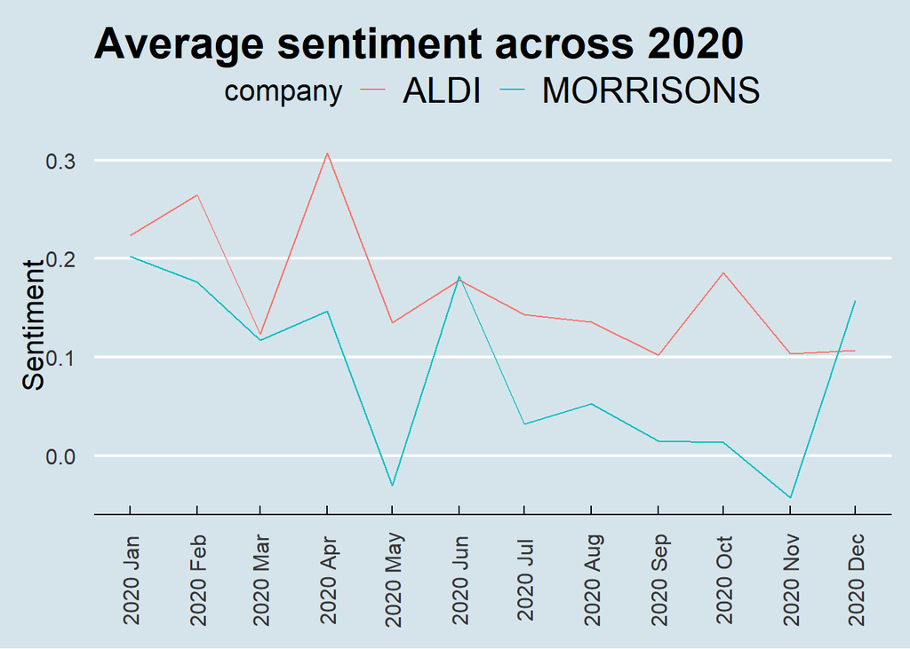

```r
# original graphing, group data before visualisation

#call library
library(ggthemes)

# prepare data
prep.data<-second.set%>%filter(Year==2020)%>%group_by(Month, company)%>%summarise(avg.sent=mean(ave_sentiment))

#plot
library(ggplot2)
ggplot(prep.data,
       aes(x=Month, y= avg.sent, color=company)) +
       geom_line()+

  geom_vline(xintercept = 3.2, colour = "red")+
       scale_x_date(date_breaks = "month",
               date_labels = "%Y %b")+
       labs(title = 'Average sentiment across 2020',
        x = NULL,
        y = 'Sentiment') +
    theme_economist() +
    theme(axis.text.x = element_text(colour="grey20", size=12, angle=90, hjust=.5, vjust=.5),
                        axis.text.y = element_text(colour="grey20", size=12),
          text=element_text(size=16))
```

#### SENTIMENT STATISTICALLY DIFFERENT ?

I decided to subject the differences in average sentiment across the two companies to a little more scrutiny. It was time for a t-test!

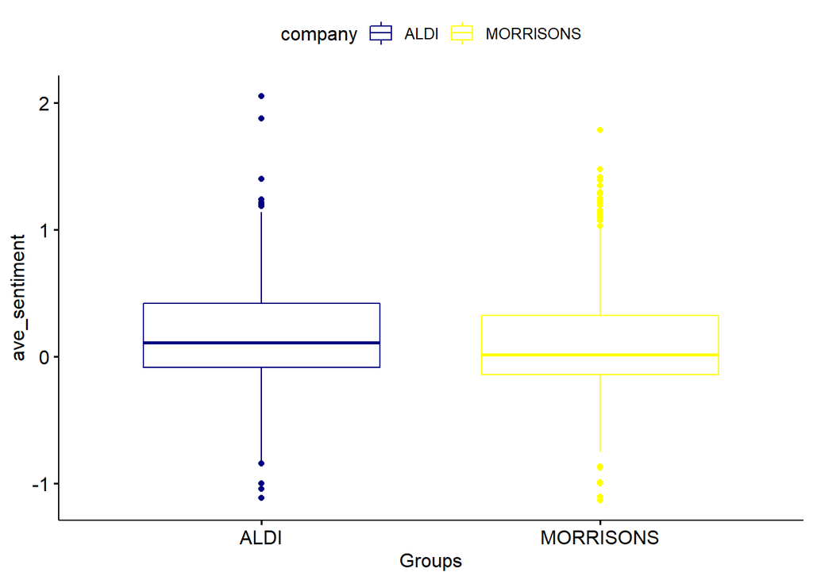

```r
#subset 2020 for sentiment comparison

twenty.twenty<-second.set[second.set$Year %in% 2020,]

library("ggpubr")
ggboxplot(twenty.twenty, x = "company", y = "ave_sentiment",
          color = "company", palette = c("navy", "yellow"),
        ylab = "ave_sentiment", xlab = "Groups")
```

```r
t.table<-twenty.twenty%>%group_by(company)%>%
  summarise(
    count = n(),
    overall.mean = mean(ave_sentiment, na.rm = TRUE),
    sd = sd(ave_sentiment, na.rm = TRUE)
  )
```

```r
t.test(ave_sentiment ~ company, data = twenty.twenty)
```

```
##
##  Welch Two Sample t-test
##
## data:  ave_sentiment by company
## t = 3.138, df = 1280.1, p-value = 0.00174
## alternative hypothesis: true difference in means between group ALDI and group MORRISONS is not equal to 0
## 95 percent confidence interval:
##  0.02527522 0.10958849
## sample estimates:
##      mean in group ALDI mean in group MORRISONS
##               0.1691646               0.1017328
```

Here, I used Welch’s t-test, otherwise known as an unequal variances t-test. This test assesses whether two populations share equal means. In keeping with tradition, I employed an alpha level of 0.05: the results obtained suggest that Aldi employees are indeed happier than their Morrisons counterparts (p<0.05).

### INSPECTING N-GRAMS!

In the domain of computational linguistics, an N-gram is a contiguous sequence of n objects from a selected sample of text/speech. The objects can be words, phonemes, or syllables.

In this particular analysis, I decided to solely examine word related N-grams.A unigram is simply a one-word sequence, whereas a bigram is a two-word sequence, and not surprisingly a trigram is a three-word sequence of words! I commenced my analysis of N-grams by looking at the most commonly occurring single words featured within the PROs sections.

```r
# custom stop words, to be removed from analysis
custom_stop_words <- tibble(word = c("na","aldi", "morrisons"))
```

```r
word_frequency1<-COMBINED.df%>%filter(company=="ALDI")%>%unnest_tokens(word,PROS)%>%anti_join(stop_words)%>%anti_join(custom_stop_words)%>%drop_na()%>%count(word, sort=TRUE)
```

```r
AP<-word_frequency1%>%top_n(8)%>%mutate(word = reorder(word, n))%>%ggplot(aes(x=n, y=word))+                            geom_col(color = "tan1", fill = "navy")+
  labs(title = "Aldi",
       subtitle = "Aldi most Frequent PRO words",
       x = "",
       y = "Frequency",
       caption = "Aldi") +
  theme(plot.caption = element_text(face = "italic"))
```

```r
word_frequency2<-COMBINED.df%>%filter(company=="MORRISONS")%>%unnest_tokens(word,PROS)%>%anti_join(stop_words)%>%anti_join(custom_stop_words)%>%drop_na()%>%count(word, sort=TRUE)
```

```r
MP<-word_frequency2%>%top_n(8)%>%mutate(word = reorder(word, n))%>%ggplot(aes(x=n, y=word))+                            geom_col(color = "yellow", fill = "seagreen")+
labs(title = "Morrisons",
       subtitle = "Morrisons most Frequent PRO Words",
       x = "",
       y = "",
       caption = "Morrisons") +
  theme(plot.caption = element_text(face = "italic"))
```

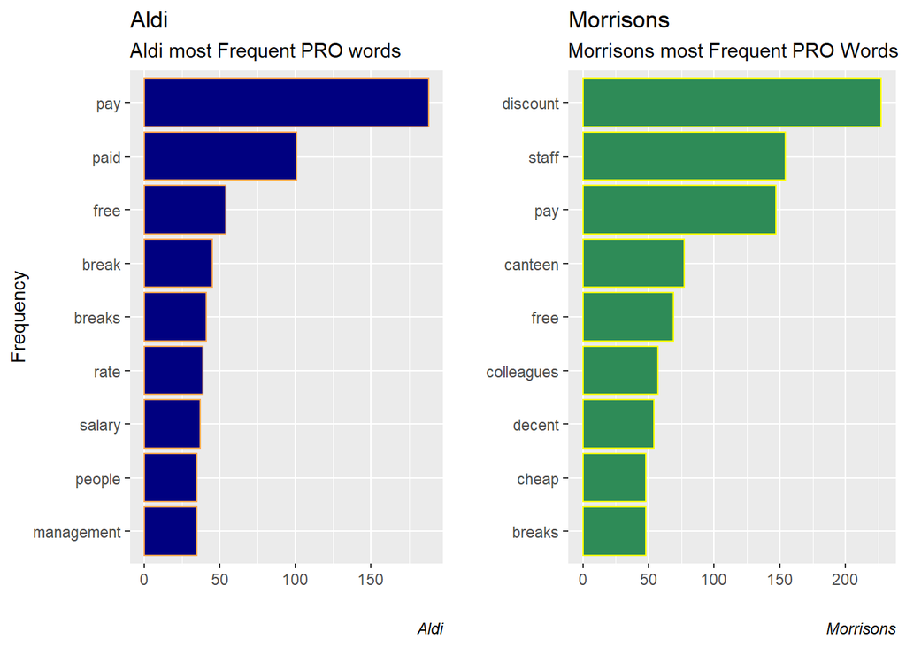

```r
library(gridExtra)
grid.arrange(AP, MP, nrow = 1)
```

### MOST FRQUENT CON WORDS

I decided to compare the most frequently occurring single words in the CONs sections

```r
word_frequency_CONS.A<-COMBINED.df%>%filter(company=="ALDI")%>%unnest_tokens(word,CONS)%>%anti_join(stop_words)%>%anti_join(custom_stop_words)%>%drop_na()%>%count(word, sort=TRUE)
```

```r
AC<-word_frequency_CONS.A%>%top_n(8)%>%mutate(word = reorder(word, n))%>%ggplot(aes(x=n, y=word))+                            geom_col(color = "tan1", fill = "navy")+
  labs(title = "Aldi",
       subtitle = "Aldi's most frequent CON related words",
       x = "",
       y = "Frequency",
       caption = "Aldi") +
  theme(plot.caption = element_text(face = "italic"))
```

```r
word_frequency_CONS.B<-COMBINED.df%>%filter(company=="MORRISONS")%>%unnest_tokens(word,CONS)%>%anti_join(stop_words)%>%anti_join(custom_stop_words)%>%drop_na()%>%count(word, sort=TRUE)
```

```r
MC<-word_frequency_CONS.B%>%top_n(8)%>%mutate(word = reorder(word, n))%>%ggplot(aes(x=n, y=word))+                            geom_col(color ="yellow", fill = "seagreen")+
labs(title = "Morrisons",
       subtitle = "Top Morrisons CON related words",
       x = "",
       y = "",
       caption = "Morrisons") +
  theme(plot.caption = element_text(face = "italic"))
```

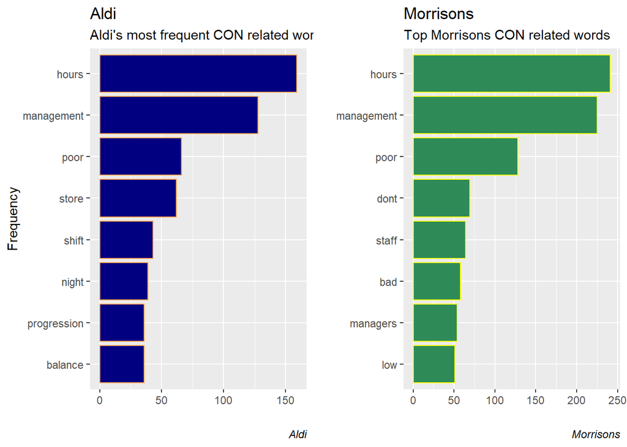

```r
library(gridExtra)
grid.arrange(AC, MC, nrow = 1)
```

### BIGRAMS

I went on to examine bigrams for Morrisons employees commencing with a comparison of the most frequently employed bigrams in the OPINION section.Below, I analysed the frequency with which two particular words appeared together consecutively across the text featured in the `OPINION` section

```r
#extract bigrams
MORRISON_bigrams <- second.set %>%filter(company=="MORRISONS")%>%
unnest_tokens(bigram, OPINION, token = "ngrams", n = 2)
```

I was then easily able to discover the words that co-occur with the greatest frequency:

```r
#display bigrams in descending order
MORRISON_bigrams %>%
count(bigram, sort = TRUE)
```

[output not shown]

```r
library(tidyr)

MORRISON_bigrams_separated <- MORRISON_bigrams %>%
separate(bigram, c("word1", "word2"), sep = " ")

MORRISON_bigrams_filtered <- MORRISON_bigrams_separated %>%
  filter(!word1 %in% stop_words$word) %>%
  filter(!word2 %in% stop_words$word)%>%filter(!word1 %in% custom_stop_words$word) %>%
  filter(!word2 %in% custom_stop_words$word)%>%unite(bigram, word1, word2, sep = " ")
```

```r
#arrange bigrams in descending order
MORRISON_bigram_count <- MORRISON_bigrams_filtered%>% ungroup()%>% count(bigram, sort = TRUE)
```

```r
#remove row 2 as NA
MORRISON_bigram_count<-MORRISON_bigram_count[-1,]
```

```r
# arrange graphical display of top Morrison bigrams
BMC<-MORRISON_bigram_count%>%top_n(10)%>% mutate(bigram = reorder(bigram, n))%>%ggplot(aes(bigram, n)) +
geom_col(color = "yellow", fill = "seagreen") +
ggtitle("Top bigrams given by Morrison employees") +
xlab(NULL) +
ylab(NULL) +
coord_flip()
```

### ALDI BIGRAMS

It was time to examine the OPINION related bigrams for Aldi employees.

```r
ALDI_bigrams <-second.set %>%filter(company=="ALDI")%>%
unnest_tokens(bigram, OPINION, token = "ngrams", n = 2)
```

```r
ALDI_bigrams %>%
count(bigram, sort = TRUE)
```

```r
library(tidyr)

ALDI_bigrams_separated <- ALDI_bigrams %>%
separate(bigram, c("word1", "word2"), sep = " ")

ALDI_bigrams_filtered <- ALDI_bigrams_separated %>%
  filter(!word1 %in% stop_words$word) %>%
  filter(!word2 %in% stop_words$word)%>%filter(!word1 %in% custom_stop_words$word) %>%
  filter(!word2 %in% custom_stop_words$word)%>%unite(bigram, word1, word2, sep = " ")
```

```r
#arrange bigrams in descending order
ALDI_bigram_count <- ALDI_bigrams_filtered%>% ungroup()%>% count(bigram, sort = TRUE)
```

```r
#remove row 2 as NA
ALDI_bigram_count<-ALDI_bigram_count[-2,]
```

```r
# arrange graphical display of top Morrison bigrams
BAC<-ALDI_bigram_count%>%top_n(10)%>% mutate(bigram = reorder(bigram, n)) %>%ggplot(aes(bigram, n)) +
geom_col(color = "tan1", fill = "navy") +
ggtitle("Top bigrams given by Aldi employees") +
xlab(NULL) +
ylab(NULL) +
coord_flip()
```

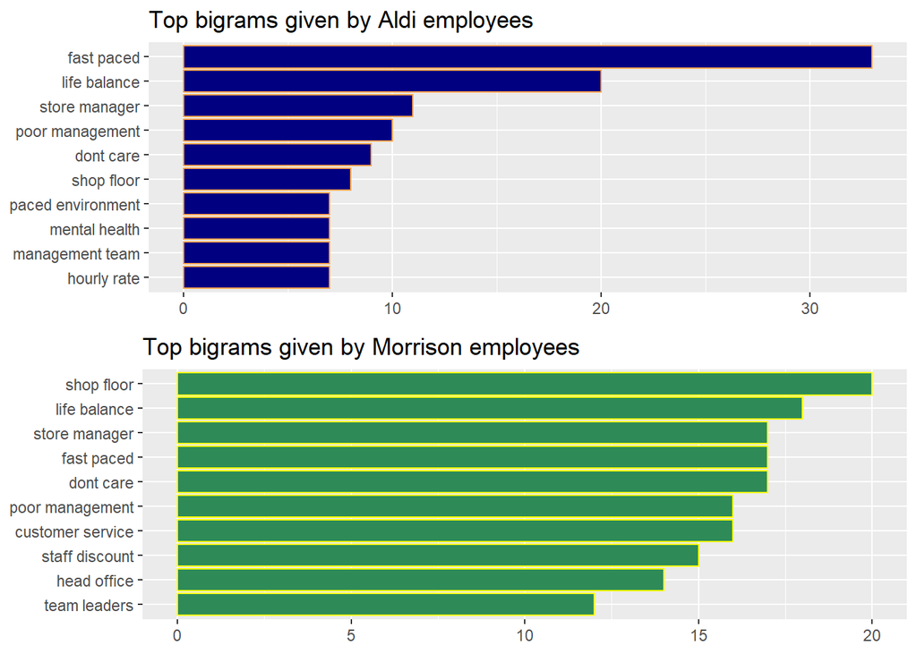

```r
library(gridExtra)
grid.arrange(BAC, BMC, nrow = 2)
```

### MOST POPULAR BIGRAM ‘PROS’

It was time to compare the most frequent bigrams featured in the PROs section

```r
MORRISON_bigrams_PROS <- second.set %>%filter(company=="MORRISONS")%>%
unnest_tokens(bigram, PROS, token = "ngrams", n = 2)
```

```r
MORRISON_bigrams_PROS %>%
count(bigram, sort = TRUE)
```

```r
library(tidyr)

MORRISON_bigrams_separated_PROS <- MORRISON_bigrams_PROS %>%
separate(bigram, c("word1", "word2"), sep = " ")

MORRISON_bigrams_filtered_PROS <- MORRISON_bigrams_separated_PROS %>%
  filter(!word1 %in% stop_words$word) %>%
  filter(!word2 %in% stop_words$word)%>%filter(!word1 %in% custom_stop_words$word) %>%
  filter(!word2 %in% custom_stop_words$word)%>%unite(bigram, word1, word2, sep = " ")
```

```r
#arrange bigrams in descending order
MORRISON_bigram_count_PROS <- MORRISON_bigrams_filtered_PROS%>% ungroup()%>% count(bigram, sort = TRUE)
```

```r
#remove row 2 as NA
MORRISON_bigram_count_PROS<-MORRISON_bigram_count_PROS[-1,]
```

```r
# arrange graphical display of top 5 Morrison bigrams
BMCP<-MORRISON_bigram_count_PROS%>%top_n(5)%>% mutate(bigram = reorder(bigram, n)) %>%ggplot(aes(bigram, n)) +
geom_col(color = "yellow", fill = "seagreen") +
ggtitle("Top 5 bigram PROS given by Morrison employees") +
xlab(NULL) +
ylab(NULL) +
coord_flip()
```

I then examined the PRO related bigrams for Aldi employees

```r
ALDI_bigrams_PROS <-second.set %>%filter(company=="ALDI")%>%
unnest_tokens(bigram, PROS, token = "ngrams", n = 2)
```

```r
ALDI_bigrams_PROS %>%
count(bigram, sort = TRUE)
```

```r
library(tidyr)

ALDI_bigrams_separated_PROS <- ALDI_bigrams_PROS%>%
separate(bigram, c("word1", "word2"), sep = " ")

ALDI_bigrams_filtered_PROS <- ALDI_bigrams_separated_PROS%>%
  filter(!word1 %in% stop_words$word) %>%
  filter(!word2 %in% stop_words$word)%>%filter(!word1 %in% custom_stop_words$word) %>%
  filter(!word2 %in% custom_stop_words$word)%>%unite(bigram, word1, word2, sep = " ")
```

```r
#arrange bigrams in descending order
ALDI_bigram_count_PROS <- ALDI_bigrams_filtered_PROS%>% ungroup()%>% count(bigram, sort = TRUE)
```

```r
#remove row 2 as NA
ALDI_bigram_count_PROS<-ALDI_bigram_count_PROS[-1,]
```

```r
# arrange graphical display of top 5 Aldi bigrams
B.ALDI.PRO<-ALDI_bigram_count_PROS%>%top_n(5)%>% mutate(bigram = reorder(bigram, n)) %>%ggplot(aes(bigram, n)) +
geom_col(color = "tan1", fill = "navy") +
ggtitle("Top 5 Aldi bigram PROs bigrams given by Aldi employees") +
xlab(NULL) +
ylab(NULL) +
coord_flip()
```

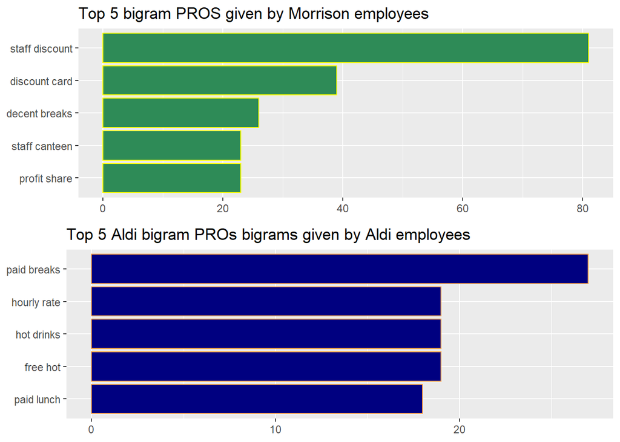

```r
library(gridExtra)
grid.arrange(BMCP, B.ALDI.PRO, nrow = 2)
```

Morrisons employees seem to place great value on `staff discounts`, whereas Aldi employees appear to appreciate `paid breaks` above all.